# Challenge Data Census US

S2 2019

L.RANT

13 décembre, 2019

# Introduction

Dans la deuxième partie, nous utilisons différentes techniques de pré-traitement pour regrouper les variables et les modalités. Ensuite nous faisons une reduction du jeu de données afin de pouvoir faire correctement les predictions.

Dans la troisième partie du projet, nous construisons des modèles prédictifs utilisant différents algorithmes. Nous appliquons les reseaux de neurones, k plus proche voisins, les forêts aléatoires, l’arbre de décision etc … Nous testerons la précision des modèles construits à la fois sur des données d’apprentissage et des données de test-validation.

# 1.Chargement des données et modification de type ou de libellé

Cette première partie comporte des analyses statistiques et elle nous aide à comprendre les données. Nous allons explorer ce jeu de données.

Nous effectuons le chargement des données et des packages nécessaires à nos travaux.

Voici la liste exhaustive des variables explicatives :

```
 [1] "age"
 [2] "class of worker"
 [3] "detailed industry recode "
 [4] "detailed occupation recode"
 [5] "education"
 [6] "wage per hour"
 [7] "enroll in edu inst last wk"
 [8] "marital stat"
 [9] "major industry code"
[10] "major occupation code"
[11] "race"
[12] "hispanic origin"
[13] "sex"
[14] "member of a labor union"
[15] "reason for unemployment"
```

[output cut: 26 more lines]

Pour éviter des risques avec la présence d’espaces dans les noms de variables, nous préférons renommer nos variables avec des noms sans espace. Dans notre espace de travail, nous appellerons désormais “Census” le jeu de données correspondant à “data_train” pour conserver l’intégrité de data_train.

## 1.1 Aperçu général

La dimension de notre tableau est :

```
[1] 199526     41
```

soit, 41 colonnes (variables) et 199526 lignes.

Les types de variables sont :

```
 factor integer
     29      12
```

Comme nous pouvons le voir, nous avons 29 colonnes qui sont qualitatives et 12 qui sont quantitatives. Afin de voir quels sont les modalités de chaque variable factorielle, nous écrivons la fonction **levels_factors()**, qui prend comme argument une trame de données, et que nous appliquons à notre jeu de données Census (Voir Annexes)

Le nombre de modalités pouvant être très important et rendant difficile l’analyse, nous serons certainement amenés à regrouper des modalités de certaines variables, ou des variables entre elles.

## 1.2 Remarques sur les types de variables

Nous observons que certaines variables reconnues comme quantitatives sont en fait des variables qualitatives (ce sont des codes pour désigner l’appartenance à une classe) :

- detailed industry recode
- detailed occupation recode
- business or self employed
- veterans benefits

La variable “year” constitue un cas un peu particulier, puisque c’est une variable temporelle, ici reconnue comme une variable quantitative alors qu’on devrait elle aussi la considérer comme une variable qualitative avec deux modalités. Nous allons changer les types de ces variables.

Pour les autres variables quantitatives, le choix de discrétiser ou non est plus ouvert, nous expliquerons plus loin nos choix.

après ces transformations, nous avons désormais :

```
 factor integer
     34       7
```

soit 34 colonnes qui sont catégorielles (qualitatives) et 7 qui sont entières (quantitatives).

## 1.2 Distribution de la variable “outcome” et distribution des manquants

# 1.2.1 Variable “outcome”

Voici la distribution des données pour la variable **outcome**

- nombre de colonne: 41
- nombre de ligne: 199526
- proportion de high salary: 6.2%
- proportion de low salary: 93.8%

La proportion de salaire faible (-50 000$) est très importante, nos données ne sont pas équilibrées par rapport à cette variable **outcome**. Ce constat est important et nous en tiendrons compte lorsque nous formerons nos modèles.

# 1.2.2 Données manquantes

Nous allons analyser les données manquantes, et les variables les plus concernées par ces manquants. Voici le nombre total de valeurs manquantes :

```
Nombre de données manquantes:  415836
```

```
[ 415836 / ( 199526 x 41 ) ] = 5.083218 %
```

Ce nombre de cellules vides dans notre jeu de données est assez faible si on le compare au nombre total de cellules.

Mesurons le nombre de ligne avec au moins une données manquantes :

```
 FALSE   TRUE
104452  95074
```

```
Nous avons 52.35007 % de lignes avec une valeur manquante
```

Soit 104452 lignes fausse avec au moins une valeur manquante et 95074 lignes sans valeur manquante. Ce qui est très important.

Observons la répartition de ces manquants par variables :

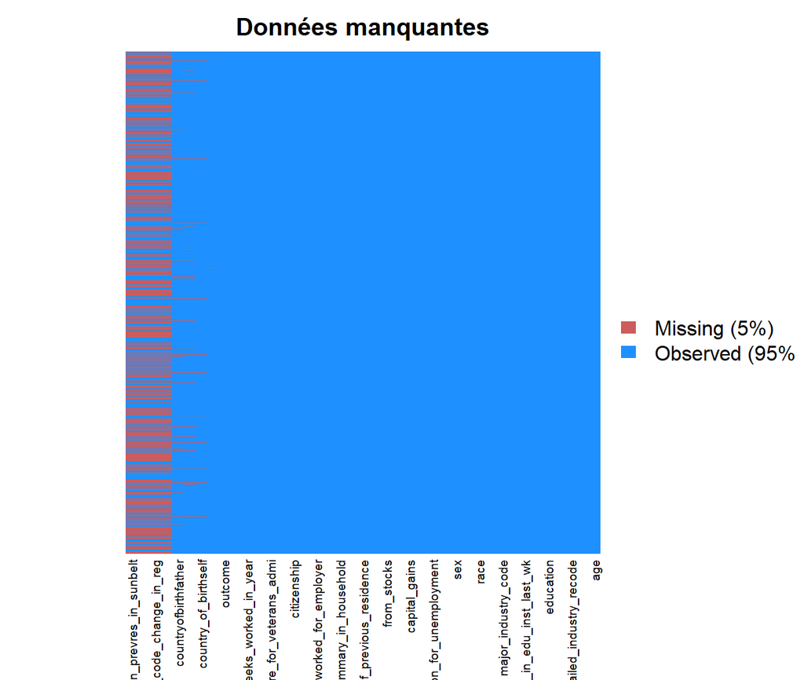

Nombre de valeurs uniques par variable

|  | x |
| --- | --- |
| age | 91 |
| class_of_worker | 9 |
| detailed_industry_recode | 52 |
| detailed_occupation_recode | 47 |
| education | 17 |
| wage_per_hour | 1224 |
| enroll_in_edu_inst_last_wk | 3 |
| marital_stat | 7 |
| major_industry_code | 24 |
| major_occupation_code | 15 |
| race | 5 |
| hispanic_origin | 10 |
| sex | 2 |
| member_of_a_labor_union | 3 |
| reason_for_unemployment | 6 |
| full_or_part_time_employment_stat | 8 |
| capital_gains | 130 |
| capital_losses | 112 |
| from_stocks | 1479 |
| tax_filer_stat | 6 |
| region_of_previous_residence | 6 |
| state_of_previous_residence | 51 |
| detailed_household_and_family_stat | 38 |
| detailed_household_summary_in_household | 8 |
| migration_code_changeinmsa | 10 |
| migration_code_change_in_reg | 9 |
| migration_code_move_with_in_reg | 10 |
| live_int_his_house_1_year_ago | 3 |
| migration_prevres_in_sunbelt | 4 |
| num_persons_worked_for_employer | 7 |
| family_members_under_18 | 5 |
| countryofbirthfather | 43 |
| country_of_birthmother | 43 |
| country_of_birthself | 43 |
| citizenship | 5 |
| business_or_selfemployed | 3 |
| fill_inc_questionnaire_for_veterans_admi | 3 |
| veterans_benefits | 3 |
| weeks_worked_in_year | 53 |
| year | 2 |
| outcome | 2 |

Voici les variables comportant des valeurs manquantes et le nombre de valeurs manquantes pour chacunes d’elles :

On a donc 8 variables avec des données manquantes.

- 99665 valeurs pour chaques variables “migration_prevres_in_sunbelt”,“migration_code_changeinmsa”, “migration_code_move_with_in_reg”,“migration_code_move_with_in_reg”. En cherchant à comprendre pourquoi on observe exactement le même nombre de manquants sur ces 4 variables, on observe que toutes les données de l’année 1995 sont manquantes pour ces variables.
- 686 valeurs pour la variable “state_of_previous_residence” soit (686/ 199526) soit 0.34% des donneées de la variable state_of_previous_residence
- 6821 valeurs pour la variable countryofbirthfather
- 6170 valeurs pour la variable country_of_birthmother
- 3499 valeurs pour la variable country_of_birthself

A ce stade, nous nous limitons à coder les NA en “inconnu”. A part pour les 4 premières variables citées ci dessous, c’est une proportion de manquants relativement faible, et nous pouvons en faire une modalité. Par la suite, on verra comment gérer la modalité **Inconnu** par rapport à notre objectif de prédiction d’outcome.

# 2.Exploration

## 2.1 Variables quantitatives

### 2.1.1 Indicateurs statistiques

```
=============================================================================================
Statistic                          N    Min Pctl(25) Median  Mean   Pctl(75)  Max   St. Dev.
---------------------------------------------------------------------------------------------
age                             199,526  0     15      33   34.502     50      90    22.351
wage_per_hour                   199,526  0     0       0    54.948     0     9,999   274.167
capital_gains                   199,526  0     0       0    430.726    0     99,999 4,666.440
capital_losses                  199,526  0     0       0    36.389     0     4,608   268.271
from_stocks                     199,526  0     0       0    198.124    0     99,999 1,965.004
num_persons_worked_for_employer 199,526  0     0       1     1.951     4       6      2.364
weeks_worked_in_year            199,526  0     0       8    23.106     52      52    24.399
---------------------------------------------------------------------------------------------
```

On peut remarquer qu’aucune des variables n’est constante. De telles variables n’auraient aucun intérêt pour l’analyse. Par ailleurs, les 4 variables “wage_per_hour”, “capital_gains”, “capital_losses” et “from_stock” sont distribuées de façon très déséquilibrée avec premier quartile = 3ème quartile = 0. Ce qui signifie un très grand nombre de valeur à 0. On peut supposer que les valeurs max à 9999, ou 99999 ne sont pas de vrais max mais des maxs autorisés par le nombre de digit disponibles.

### 2.1.2 Représentations graphiques

On commence par visualiser les distributions des variables via des diagrammes en barres et des histogrammes. Pour les variables ayant un grand nombre de valeurs distinctes, on les représentera via des histogrammes formant des classes.

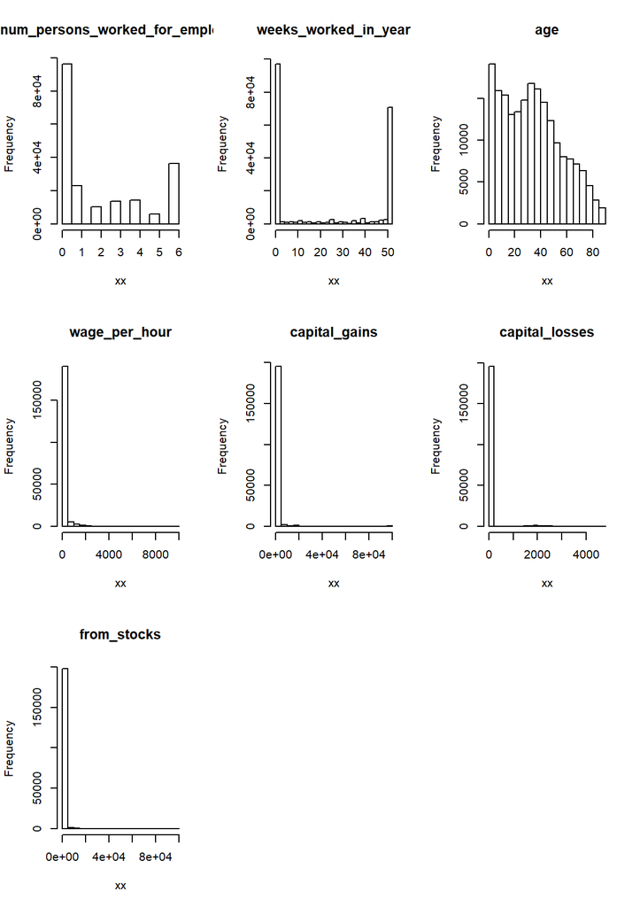

Les variables “Age” et “num_persons_worked_for_employer” ont une distribution relaitvement équilibrée. Les variables “wage_per_hour”, “capital_gains”, “capaital_losses”, “from_stocks” sont très déséquilibrées, avec énormément d’individu à 0, par rapport au nombre d’individu avec des valeurs supérieures à 0. Enfin, la variable “weeks_worked_in_year” présente beaucoup d’individu à 0 et à 52, et une proportion beaucoup plus faible se répartissant entre ces deux bornes. Pour terminer sur l’analyse univariée sur variable quantitative, nous proposons les boites à moustaches mais elles n’apportent pas grand chose par rapport à ce qui a déjà été dit.

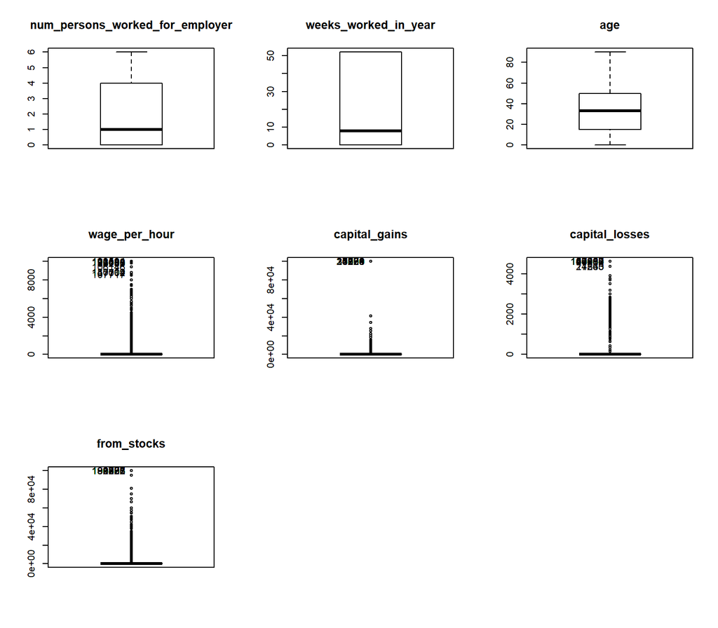

## 2.2 Variables qualitatives

Nous avons vu plus haut que certaines variables ont beaucoup de modalités, on va voir ici les modalités rares via des diagrammes en barres (on pourrait de façon équivalente visualiser cette information sous forme de tableaux). Les modalités rares pouvant avoir un impact défavorable sur l’efficacité de certains modèles, il est important de les identifier (en vue d’éventuels regroupements par la suite).

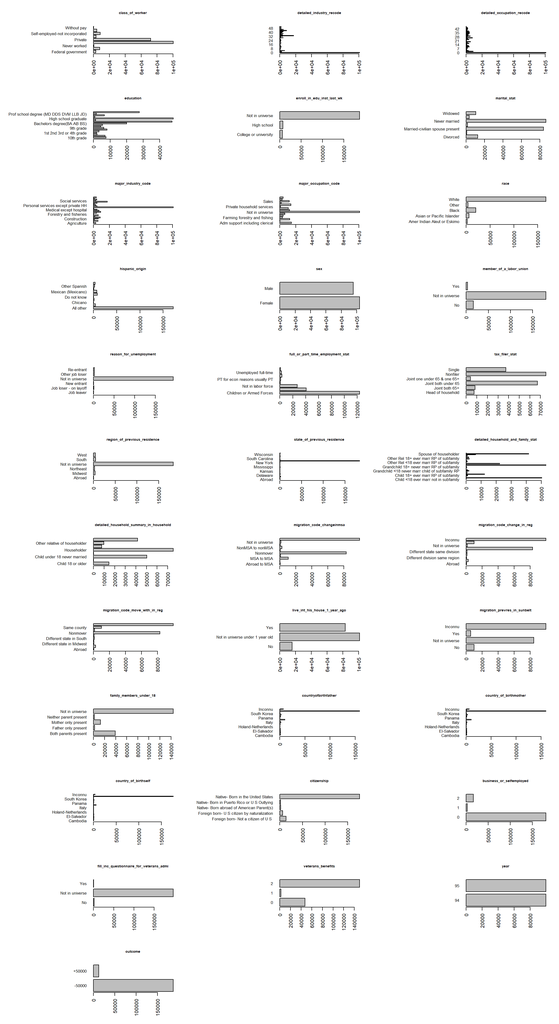

Mais nous ne pouvons envisager des regroupements qu’après avoir vérifié que ces regroupements sont pertinents vis à vis de notre variable réponse outcome, ce que nous abordons dans l’analyse bivariée. A ce stade, nous en restons donc aux constats : il y a des variables avec beaucoup de modalités et certaines modalités rares, on devra en tenir compte (traitement éventuels) si on veut utiliser ces variables pour la prédiction.

## 2.3 Analyse bivariée

Dans le cadre de notre objectif de prédiction, il convient prioritairement d’étudier le lien entre les variables explicatives et la réponse, mais on cherchera aussi par la suite à identifier des liens entre les variables explicatives

### 2.3.1 Lien entre variables explicatives et variable réponse “outcome”

#### 2.3.1.1 Lien entre outcome et les variable quantitatives

Nous pouvons comparer les boites à moustaches de nos données quantitatives en fonction d’outcome. Commençons par les variables dont on a vu plus haut qu’elles étaient très déséquilibrées (“wage_per_hour”, “capital_gains”, “capaital_losses”, “from_stocks”).

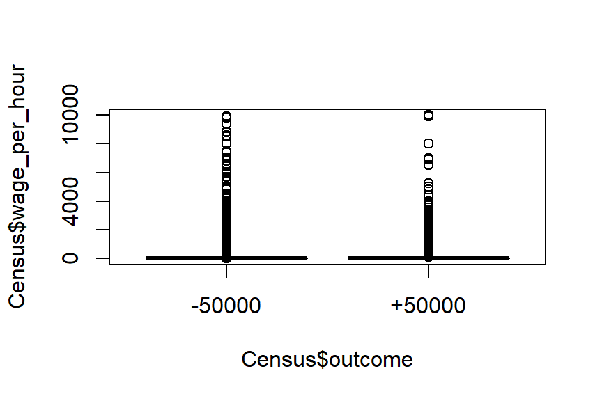

Il est dificile de conclure sur la base de cette représentation, il est en de même pour les autres (“capital_gains”, “capaital_losses”, “from_stocks”) dont nous ne donnons pas la représentation.La valeur “0”, est très fortement représentée, que cela soit pour outcome “-50000” et pour outcome “+50000”.

Avec les variables “Age”,“weeks_worked_in_year” et “num_persons_worked_for_employer” qui ont une distribution relaitvement équilibrée, on a une meilleure lisibilité :

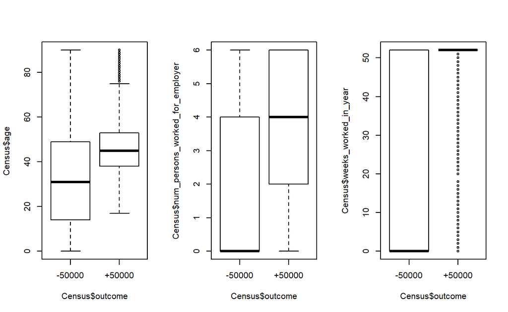

Ainsi, pour l’age, on observe un écart qui semble significatif entre les individus avec outcome “-50000” et avec outcome “+50000”. On voit qu’en moyenne les individus ont un peu plus de 30 ans (33,7) avec outcome “-50000” etun peu moins de 50 ans (46,4)avec outcome “+50000”.

Pour “num_persons_worked_for_employer”, le lien semble marqué mais on ne pourra conclure sur la force de ce lien qu’après un calcul statistique.

Parmi les individus avec outcome = +50000, il y en a une très forte proportion avec “weeks_worked_in_year” = 52. Dès maintenant, on peut supposer que cette variable jouera un rôle dans la prédiction. La présentation suivante est complémentaire à la boxplot :

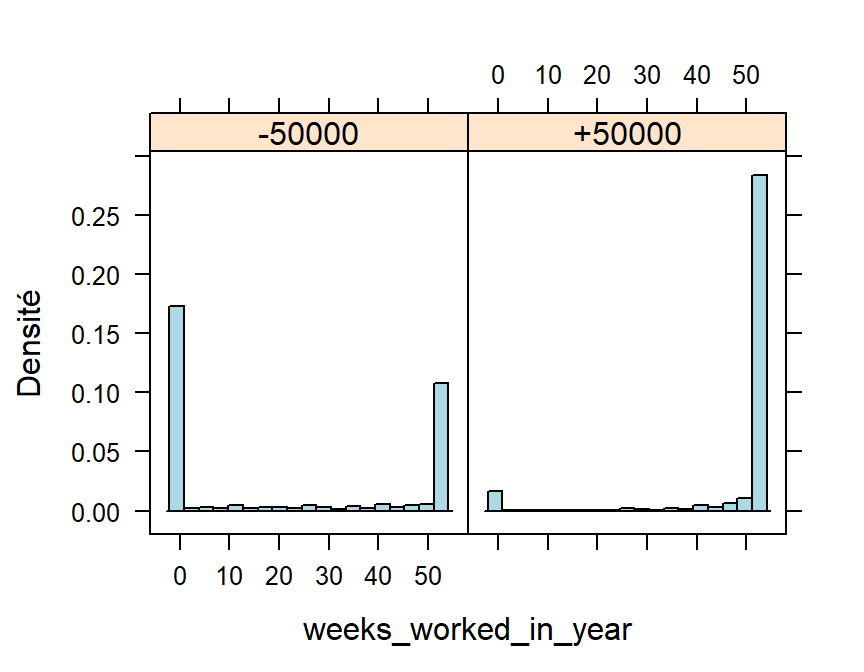

Nous pouvons imaginer une explication logique à cette distribution. Les individus avec outcome à +50000 sont très majoritairement des individus travaillant 52 semaines. Mais il y a aussi beaucoup de personnes travaillant 52 semaines et qui ont un outcome <50000. Ils ont surement un travail peu qualifié et peu rémunérateur. Les individus travaillant 0 semaine par an ont très majoritairement un outcome inférieur à 50k, mais il en existe qui ont un outcome > 50000. Ces derniers pourraient être des rentiers.

Les boites à moustache ne permettant pas de conclure quant à la force des éventuelles liaisons, voici les rapport de corrélation entre les variables quantitatives et outcome :

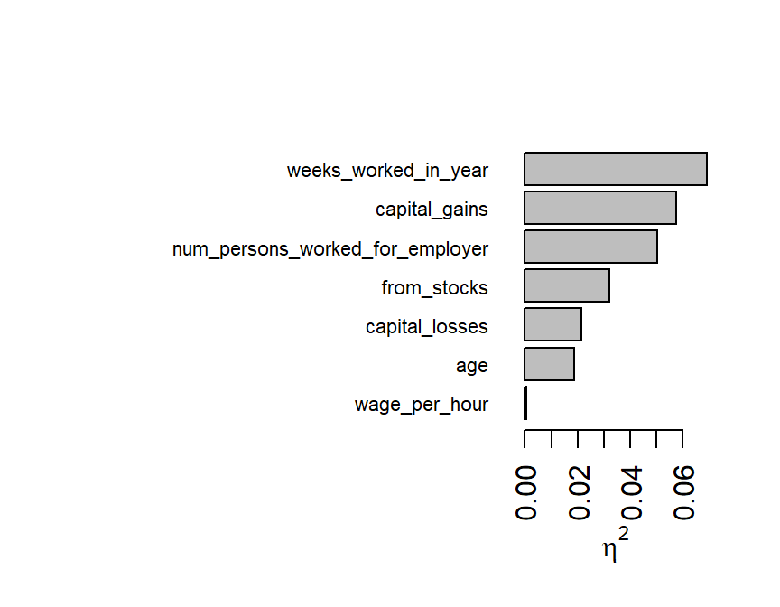

Nous trouvons la variable “weeks_worked_in_year” comme ayant le lien le plus fort avec outcome, suivi de “capital_gains”, “num_persons_worked_for_employer”, et “from_stocks”. **Une ACP** complétera ultérieurement cette approche, mais cela permet de pointer des variables pouvant jouer un rôle dans la prédiction.

“Capital_losses” et “wage_per_hour” sont moins liés à “outcome”.

Etudions un peu plus le cas de “Age” avec un graphique “proportion de outcome +50K = f(age)” :

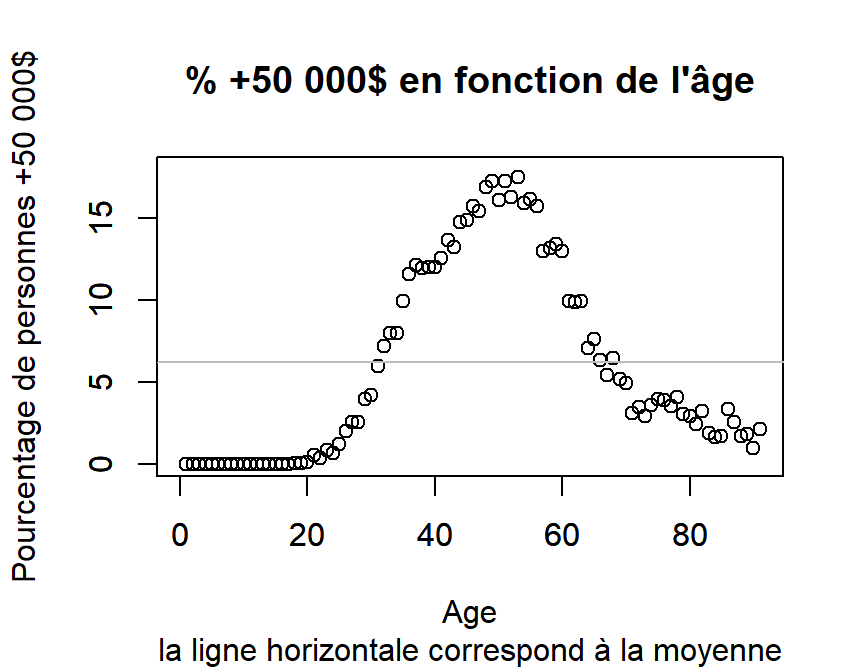

On a traité jusqu’ici l’âge comme une variable quantitative mais son traitement implique souvent de la passer en classes. Par ailleurs, dans beaucoup de domaines, l’age ne réagit pas de façon corrélée à la mesure (vitesse de course faible pour enfants et vieillards). Et dans le domaine médical, les âges faibles et très grands constituent des populations exposées à certains risques et sont regroupés. Notre courbe montre un peu la même choses, et cela nous dit que nous avons tout intérêt à réaliser des classes :

- probabilité nulle à quasi nulle d’observer outcome +50K pour les âges compris dans [0,18]
- probabilité intermédiaire d’observer outcome +50K pour les âges compris dans [19,33] et [63,90]
- probabilité forte (en comparaison à l’ensemble des données) d’observer outcome +50K pour les âges compris dans [34,62]

Cette transformation de données est une transformation “métier”, on réalise un découpage à la lumière de notre lecture du lien entre la variable “age” et la variable “outcome” et de notre objectif.On ajoute donc une variable qualitative “groupedeage”.

```
[1] "jusqu'à 18 ans" "19 à 33 ans"    "34 à 62 ans"    "63 ans et plus"
```

#### 2.3.1.2 Lien entre outcome et les variable qualitatives

Mesurons le lien entre les variables qualitatives (auxquelles nous avons donc ajouté “groupedeage” et “outcome” avec le V de Cramer (pour information, nous préférons le V de Cramer au test du Khi-deux car il est plus approprié avec un très grand nombre d’individus) :

Resultats V de CRAMER

|  | x |
| --- | --- |
| year | 0.0143384 |
| live_int_his_house_1_year_ago | 0.0259757 |
| migration_prevres_in_sunbelt | 0.0270173 |
| region_of_previous_residence | 0.0274515 |
| fill_inc_questionnaire_for_veterans_admi | 0.0280491 |
| reason_for_unemployment | 0.0282018 |
| state_of_previous_residence | 0.0316417 |
| migration_code_move_with_in_reg | 0.0364233 |
| migration_code_change_in_reg | 0.0364775 |
| migration_code_changeinmsa | 0.0375418 |
| citizenship | 0.0427754 |
| country_of_birthself | 0.0585756 |
| race | 0.0601518 |
| enroll_in_edu_inst_last_wk | 0.0648959 |
| hispanic_origin | 0.0681777 |
| country_of_birthmother | 0.0707903 |
| countryofbirthfather | 0.0720188 |
| member_of_a_labor_union | 0.0776977 |
| business_or_selfemployed | 0.0786842 |
| veterans_benefits | 0.1443710 |
| full_or_part_time_employment_stat | 0.1583704 |
| sex | 0.1583786 |
| family_members_under_18 | 0.1592051 |
| marital_stat | 0.1993344 |
| detailed_household_summary_in_household | 0.2278732 |
| tax_filer_stat | 0.2314396 |
| detailed_household_and_family_stat | 0.2417388 |
| class_of_worker | 0.2593977 |
| major_industry_code | 0.2804275 |
| detailed_industry_recode | 0.2945807 |
| major_occupation_code | 0.3665681 |
| education | 0.3897944 |
| detailed_occupation_recode | 0.4380730 |

Voyons le graphique

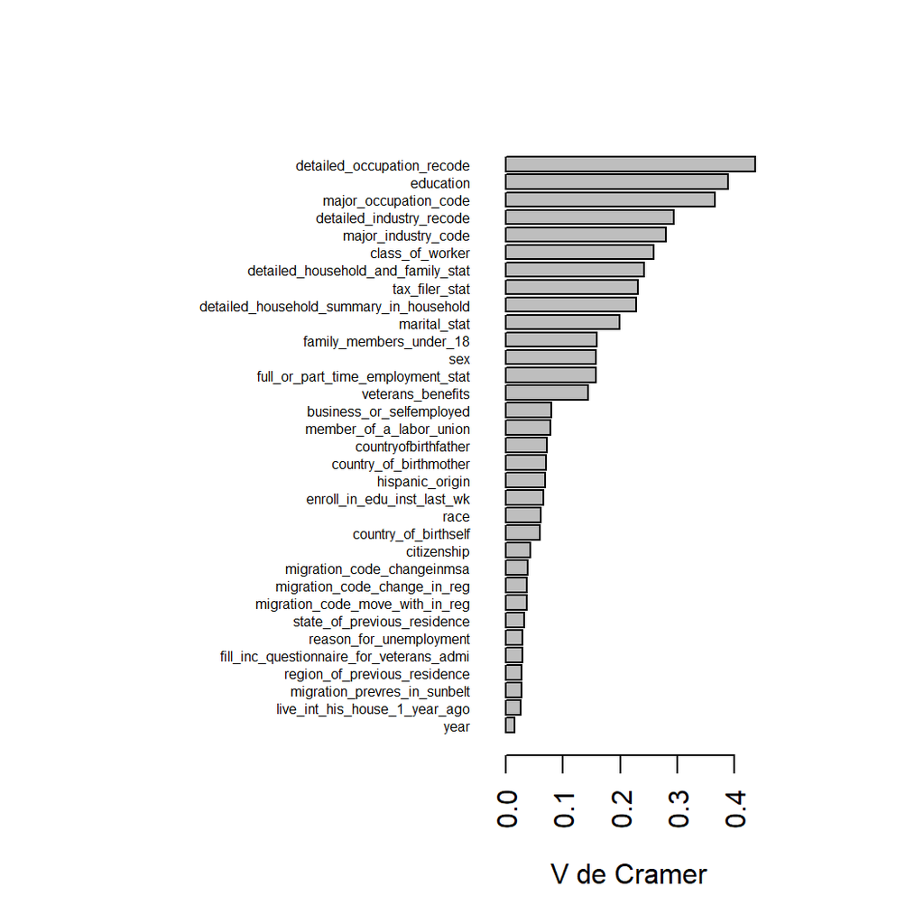

Inversement, des variables comme year, live_int_his_house_1_year_ago (par exemple) sont très peu lièes à outcome.

Ces analyses pourront être utiles en vue d’une réduction du nombre de colonnes, les variables les moins liées à outcome pourront être écartées sans impact ou avec un impact négligeable sur la qualité de la prédiction d’outcome.

### 2.3.2 Lien entre variables explicatives

#### 2.3.2.1 Variables quantitatives

Des liaisons trop fortes entre variables explicatives peuvent conduire à de grande instabilité dans les modèles. L’analyse des liaisons entre variables explicatives permettra de détecter les couples de variables les plus liées. Nous concervons la variable “age” comme valeur numérique, même si nous avons montré que pour la modélisation, la variable “groupedeage” sera plus pertinente.

Voici la **matrice des corrélations** :

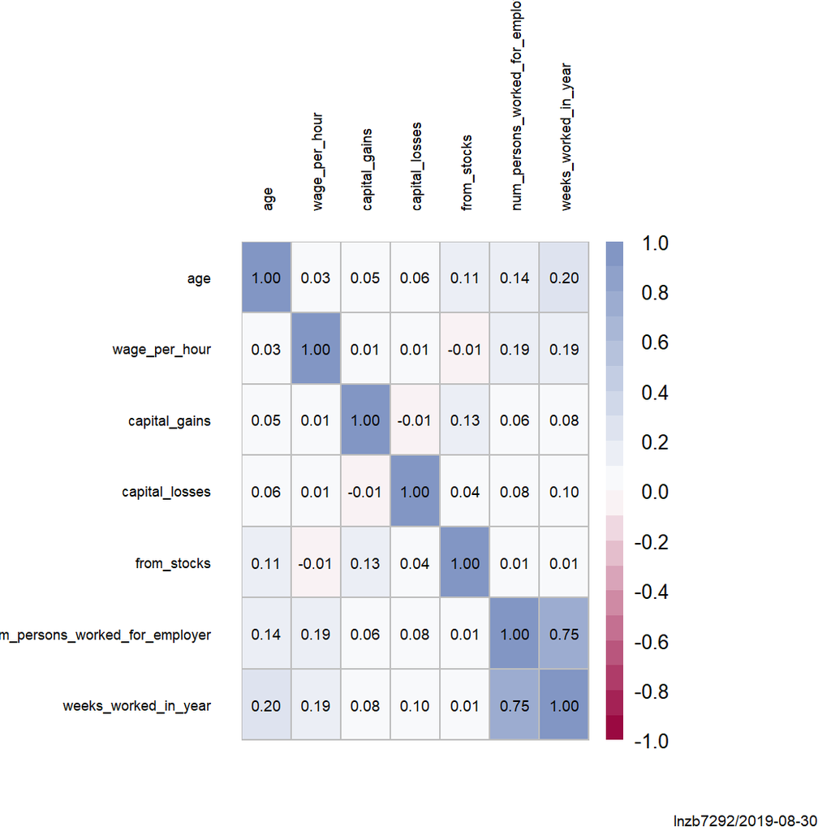

Nous n’observons pas de fortes corrélations, si ce n’est pour le couple “weeks_worked_in_year” et “num_persons_worked_for_employer”. Ci dessous, avec les coefficients de Spearman (plus adpaté si nos variables ne suivent pas une loi normale, ce qui est le cas), nous concluons de la même manière.

Voici la matrice des **corrélations avec coefficient de spearman** :

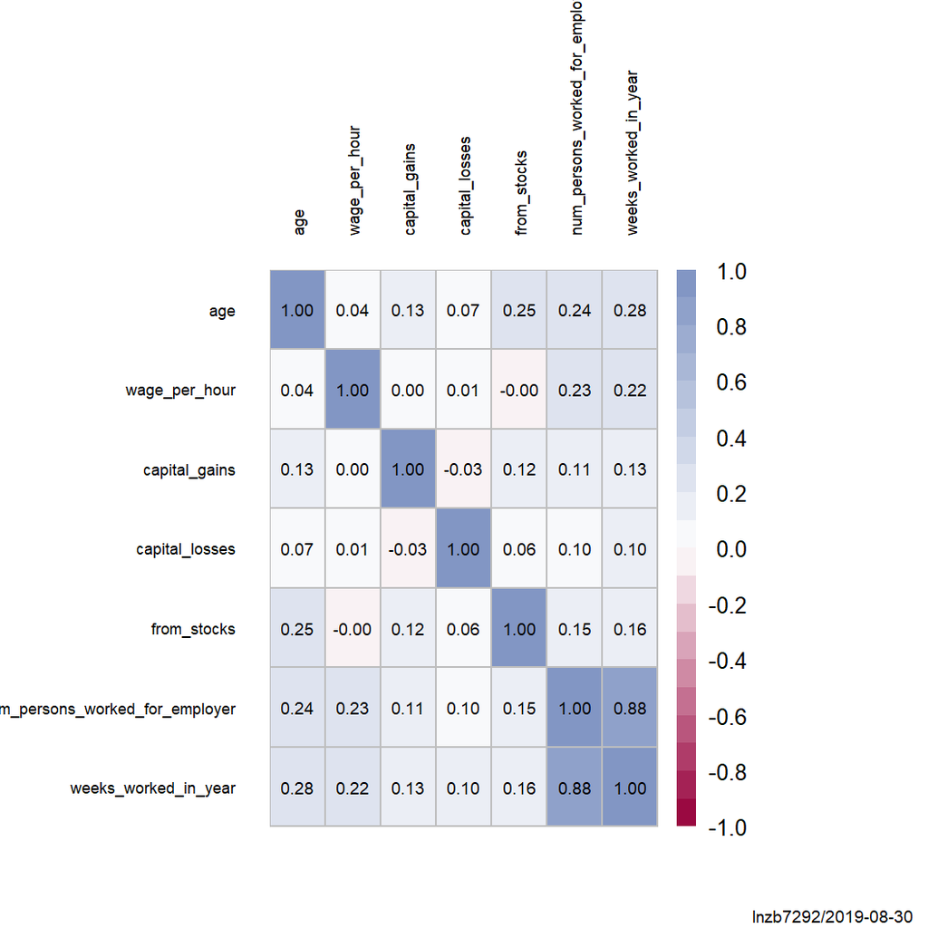

#### 2.3.2.2 Variables qualitatives entre elles

De la même façon, on détermine les V de Cramer entre les variables explicatives qualitatives.

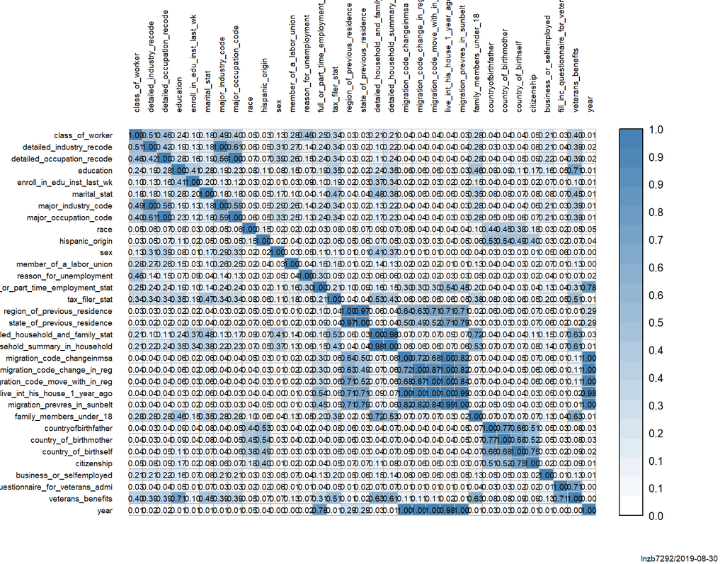

Nous observons de très fortes liaisons entre :

- detailed_industry_recode et major_industry code : c’est normal, par construction, ces données sont liées par une arborescence. On peut donc considérer qu’il y a redondance.
- idem entre major_occupation_code et detailled_occupation_code et pour region_of_previous_residence et state_of_previous_residence
- year et les 4 variables commençant par migration… : nous avons vu plus haut que cela s’explique par l’absence de données pour une valeur de year, et la présence pour l’autre valeur de year.

et des liaisons fortes entre :

- les variables commençant par migration… et live_in_this_house_previous_year
- country_birth_self avec country of birth_mother et father

ce qui est logique dans les deux cas, et qui dénote aussi une forme de redondance dans l’information.

Ces éléments nous donnent des indications pour supporter nos analyses ACM à venir.

## 2.4 Analyse multivariée

### 2.4.1 ACP sur les données quantitatives

Nous effectuons une ACP sur les données quantitatives (hormis l’age) en considérant outcome comme une variable supplémentaire quantitative.

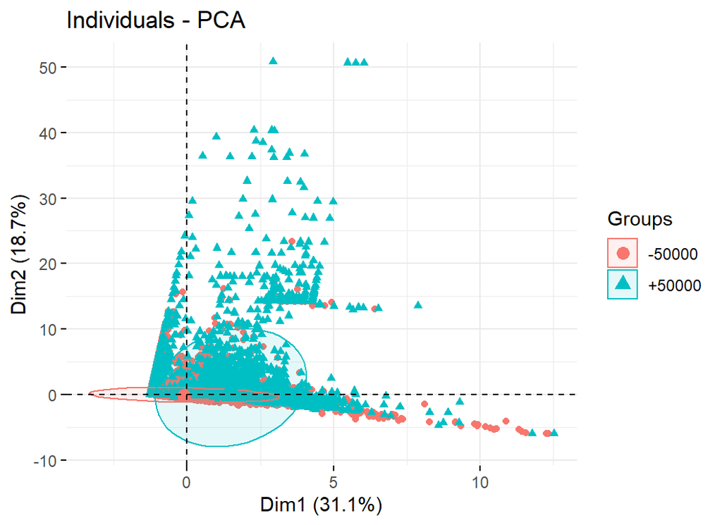

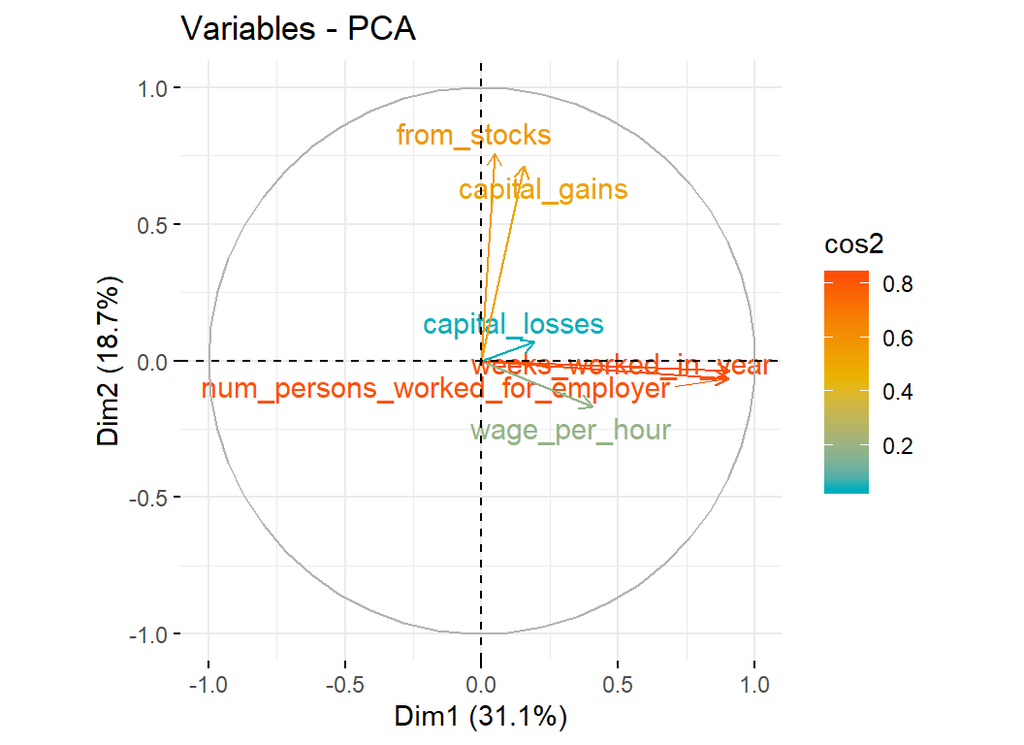

Les éléments les plus intéressants qui ressortent de l’ACP nous montre que :

- la première composante est essentiellement liée à num_persons_worked_for_employer, et weeks_worked_in_year
- la deuxième à capital_gains et from_stocks
- la troisème à capital_losses

Enfin, sur chacune de ces trois composantes, les modalités d’outcome ont des coordonnées significativement différentes, respectivement (-0.099, -0.070, -0.018) pour -50k et (1.496, 1.059, 0.278) pour +50ke. Les cos2 des deux premières composantes sont assez élevés (0.64 et 0.321), mais faible pour la troisième.

Nous pouvons conclure pour notre prédiction que les 4 variables quantitatives num_persons_worked_for_employer, et weeks_worked_in_year,capital_gains et from_stocks sont les plus susceptibles de contribuer à la qualité d’un modèle de prédiction.

wage_per_hours et capital_losses contribuent peu à la variable réponse outcome mais capital_losses est proche de outcome. C’est une variable rare qui correspond à une perte de capital et qui necessite d’avoir un capital financier.En majorité, ce sont les individus avec un revenu confortable qui possèdent un capital financier.

Nous pouvons envisager, si la modélisation nous contraint dans le nombre de variables, de :

- choisir entre num_persons_worked_for_employer, et weeks_worked_in_year, puisque ces deux variables sont très liées,
- créer une variable composite (capital_gains + from_stocks) puisque ces deux variables correspondent à des revenus et agissent dans le même sens vis à vis d’outcome.

### 2.4.2 ACM sur les données qualitatives

On réalise l’ACM en mettant la variable outcome en variable illustrative.

On gère les modalités rares (fréquence relative <5%) en effectuant de la ventilation.

**Voici le graphe des individus**

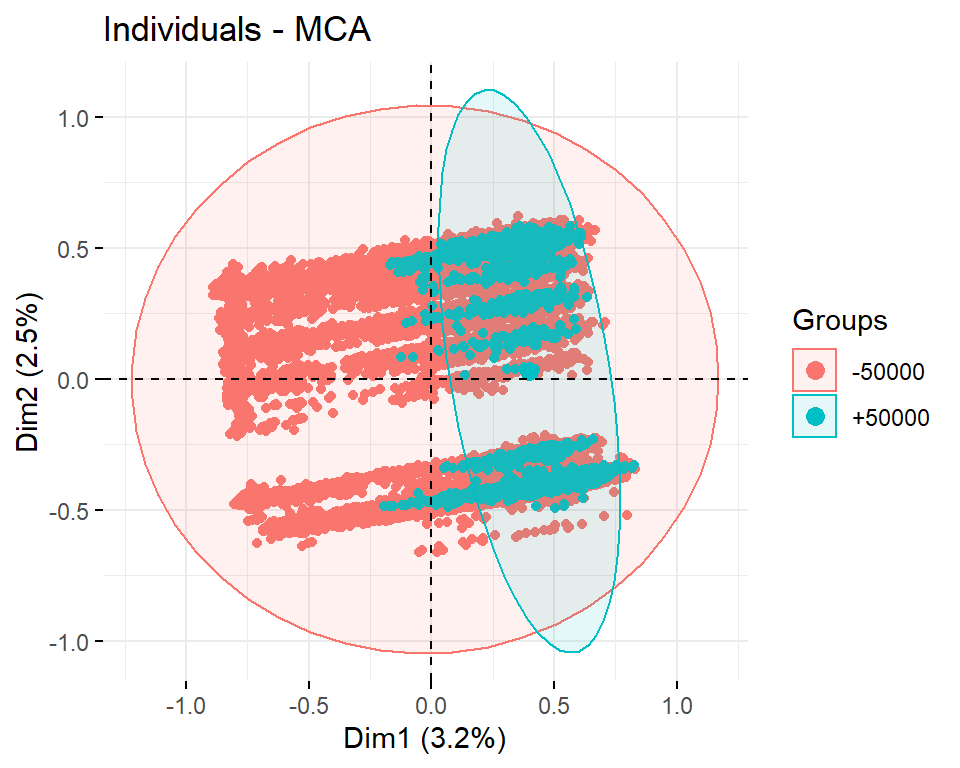

**Voici le graphe des variables avec outcome**

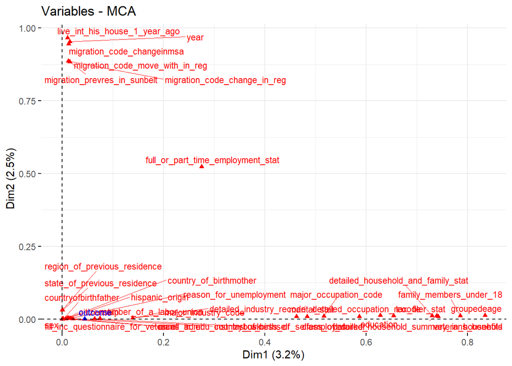

**Voici le graphe avec les modalités avec “-50000” et “+50000”**

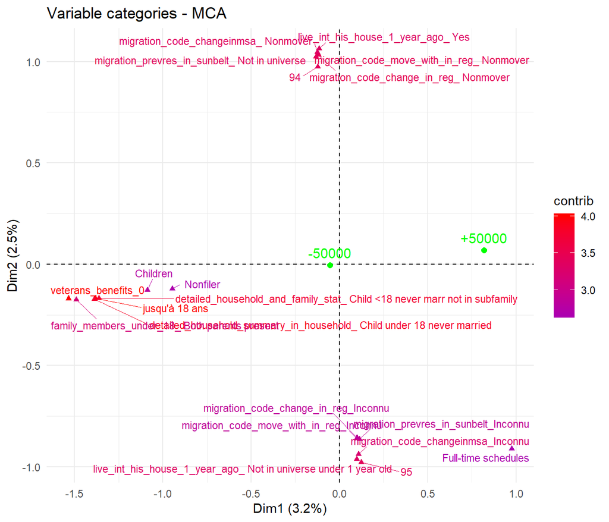

L’exploitation visuelle n’est pas facile du fait du nombre important de variables et du nombre important de modalités. Néanmoins, et en s’appuyant sur les détails que nous mettrons en annexe et des labels en rouge qui contribuent le plus, on fait apparaître un écart important sur la dimension 1 entre outcome +50k et outcome -50k.

Les contributions les plus fortes à cette dimension viennent de :

- l’age via groupedeage,
- un groupe de variables lié au type de travail (class_of_worker,detailed_industry_recode, detailed_occupation_recode, major_industry_code, major_occupation_code )
- le niveau d’éducation (education)
- la composition du foyer (detailed_household_and_family_stat, detailed_household_summary_in_household, family_members_under_18)
- le statut par rapport à des pensions ou des taxes (tax_filer_stat,veterans_benefits).

La faible repréentativité des premières dimensions limite la portée de cette acm, mais couplée avec les résultats trouvés sur les liaisons plus haut, on peut conclure que, en vue d’une modélisation, on peut retenir parmi les variables qualitatives :

- la variable “groupedeage”
- la variable “education” des variables liés au type de travail :

-la variable “detailled_occupation_recode”et nous n’utiliserons pas major_occupation_code du fait de leur liaison -la variable “detailed_industry_recode”, et nous n’utiliserons pas major_industry_code du fait de leur liaison -la variable “class_of_worker”

- la variable “tax_filler_stat”
- la variable “detailled_household_and_family_stat”, et nous n’utiliserons pas “detailled_household_summary_in_household” du fait de leur liaison.
- la variable “marital_stat”.

Si notre modèle doit être amélioré, des variables comme : “veterans_benefits”, “full_or_part_time_employment_stat”, “family_members_under_18” et “sex” pourront dans un deuxième temps être envisagés.

Pour les besoins de l’étude et pour illustrer des regroupements de modalités, nous continuons de travailler sur la modalité “country_of_birth_self”. Nous avons vu qu’elle était fortement liée à country_of_birth_mother et father. On peut choisir d’utiliser “country_of_birth_self” uniquement, sans impacter ou de façon négligeable la modélisation.

Ces variables sont plutôt logique car il est très rare d’avoir un revenu élevé avant 24 ans et sans un diplome universitaire. La classe de travail et le secteur sont aussi important car il est moins rare d’avoir un revenu supérieur à +50k$ dans le domaine de la finance que dans le batiment. De même il est logique de prendre en compte le statuts marital,full_or_part_time_employment_stat,“full_or_part_time_employment_stat”, "family_members_under_18 ou le sexe qui sont des sources d’inégalités salariales entre hommes et femmes, mères célibataires et couples sans enfants, travail à temps partiel…

Notons que les variables pour lesquels nous avions des manquants semblent avoir un intérêt limité par rapport à notre objectif de modélisation.

# 3.Pré-traitement

## 3.1 Simplifications des données

### 3.1.1 Analyses en vue d’éventuelles transformations des données qualitatives / regroupement de modalités

Afin de faciliter les analyses, nous effectuons des regroupements de modalités. Nous proposons de travailler sur quelques variables seulement On choisit des variables où il y a une logique apparente de regroupement (approche “métier”). On s’assure au préalable que ces regroupements ne vont pas nous faire perdre de l’information, et que la distribution d’outcome est homogène parmi les différentes modalités qu’on souhaite regrouper.

#### La variable “country_of_birthself”

Dans le cas de la variable “country of birth self” par exemple, on peut représenter le pourcentage de outcome +50 K pour s’assurer qu’on fait des regroupements pertinents :

```
                          -50000     +50000      Total
   Cambodia            98.130841   1.869159 100.000000
   Canada              90.275762   9.724238 100.000000
   China               92.494929   7.505071 100.000000
   Columbia            96.551724   3.448276 100.000000
   Cuba                92.210767   7.789233 100.000000
   Dominican-Republic  98.670606   1.329394 100.000000
```

Nous observons que les groupes au sens géographique sont relativement homogènes concernant la variable outcome. On peut donc procéder au regroupement avec pas ou peu de perte d’information (Asie de l’est, Asie Centrale, Amérique centrale, Amérique du sud, Europe de l’est et Europe de l’ouest).

**Création de nouveaux labels**

```
[1] " Central-America" " Central-Asia"    " East-Asia"
[4] " Europe-East"     " Europe-West"     " Outlying-US"
[7] " South-America"   " United-States"
```

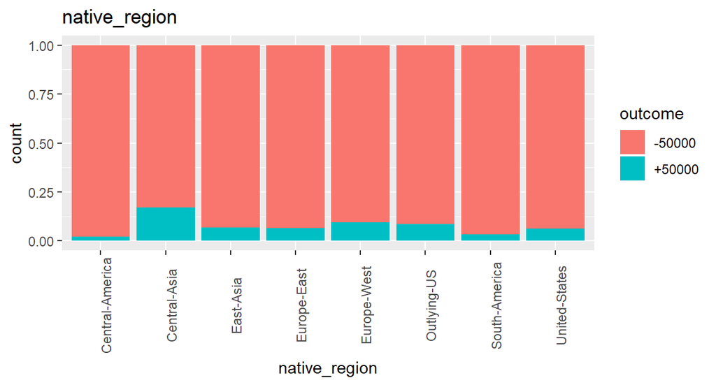

#### La variable “educ_level”

De la même manière, nous effectuons des regroupements sur le niveau d’education, pour limiter fortement le nombre de modalités avec pas ou peu de perte d’informations.

**Création de nouveaux labels**

```
[1] "CC-grad"     "College"     "grad-school" "HS-grad"     "no-HS"
```

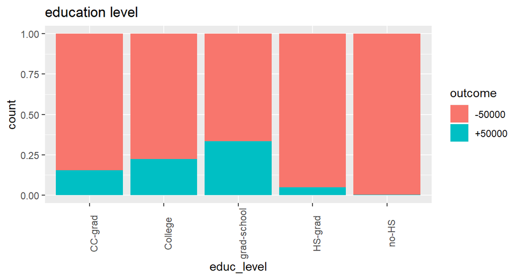

Nous pouvons analyser plus finement la distribution de outcome selon le niveau d’éducation avec un graph de type mosaïc plot :

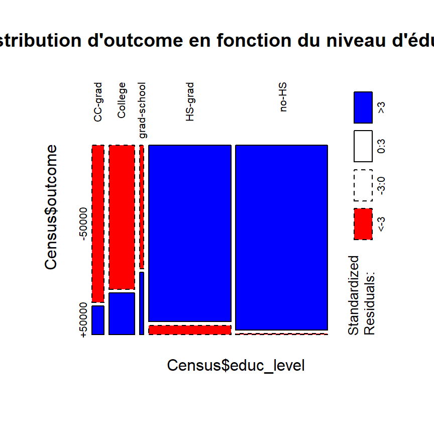

On trouve une sur-représentation de +50K pour les niveaux d’éducation CC-grad, College et Grad-school (et une sous représentation pour les HS-grad et les no-HS). Une liaison entre les variables outcome et edcu_level semble évidente, c’est quelque chose qu’on a déjà vu plus haut, mais avec ce graphique, on valide facilement des regroupements de modalités.

#### La variable “extra_outcome”

On peut définir une variable “extra_income” comme étant le montant des gains de capitaux (capital_gains) et des actions(from_stock), et discrétiser cette variable en s’intéressant uniquement aux trois modalités suivantes : extra_income inférieur à 0, nul, ou supèrieur à 0. Regardons la répartition outcome +50K/-50K pour ces trois modalités :

**Création de nouveaux labels**

```
[1] "none"     "positive"
```

En fait, nous n’observons que des gains nuls ou positif, ce qui est assez logique puisque nous n’avions pas de valeur négative pour les deux composantes de cette nouvelle variable.

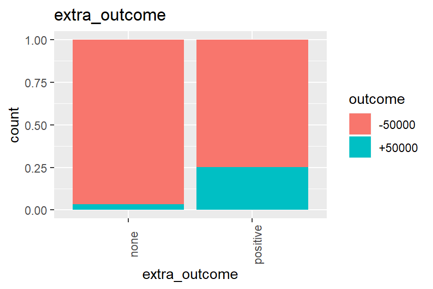

Cette répartition nous dit que les gens qui ont des revenus de capitaux, ont plus souvent des revenus du travail supérieurs à 50K$ que les gens qui n’ont pas de revenus de capitaux.

### 3.1.2 Reduction des données en colonnes

Sur le choix des variable quantitatives, nous pouvons conclure pour notre prédiction que nous garderons 4 variables quantitatives:

-num_persons_worked_for_employer

-weeks_worked_in_year

-capital_gains et from_stocks transformées en variable qualitative “extra_outcome”

Sur le choix des variables quantitatives, nous pouvons conclure pour notre prédiction que nous garderons 13 variables qualitatives :

- la variable “groupedeage”
- la variable “education” qui sera transformée en “educlevel”
- la variable “detailled_occupation_recode”
- la variable “detailed_industry_recode”
- la variable “class_of_worker”
- la variable “tax_filer_stat”
- la variable “detailled_household_and_family_stat”
- la variable “marital_stat”

Si notre modèle doit être amélioré, les variables ci-dessous pourront venir en supplément des variables ci dessus : - “veterans_benefits” - “full_or_part_time_employment_stat” - “family_members_under_18” - “sex” - “country_of_birth_self” transformée en “native_region”

Nous gardons finalement 16 variables explicatives et outcome, donc 17 variables pour commencer la modélisation.

Nous avons créé un nouveau jeu de donnée **data_Census**

La dimension de notre tableau est :

```
199526 17
```

soit 17 variables et 199526 lignes

Les types de variables sont :

```
 factor integer
     15       2
```

Nonbre de haut et faible salaires :

```
12380 lignes avec outcome = +50 000$ pour data_Census
```

```
187146 lignes avec outcome = -50 000$ pour data_Census
```

# 4.Modelisation

## 4.1 Découpage des jeux de données apprentissage et Test

Nous allons vérifier les colonnes avec des valeurs manquantes NA

```
[1] 0
```

Ici, nous avons aucune lignes avec des valeurs manquantes.

Ensuite, nous divisons l’ensemble de données apprentissage et Test.

Avant nous avions 199526 lignes. Maintenant, nous avons pour les données small_train_data:

```
155145 lignes pour la partie données d'apprentissage
```

Nous avons pour les données validation_data:

```
44381 lignes  pour la partie données de test
```

Regardons en détail le jeu de donnée small_train_data et validation_data

```
9661 lignes avec outcome = +50 000$ pour small_train_data
```

```
2719 lignes avec outcome = +50 000$ pour validation_data
```

```
145484 lignes avec outcome = -50 000$ pour small_train_data
```

```
41662 lignes avec outcome = -50 000$ pour validation_data
```

### 4.1.1 Reduction des données en lignes

Nous allons créer une petit ensemble de donnée pour reduire le nombre de lignes afin de minimiser les temps d’exécution pour plusieurs modèles. Le plus petit ensemble de données d’apprentissage “balanced_small_train_data” est échantillonné de façon aléatoire.

Nous avons 19322 lignes sur ce jeu de donnée.

Nous avons 9661 lignes avec outcome -50 000$ sur ce jeu de donnée.

Nous avons 9661 lignes avec outcome +50 000$ sur ce jeu de donnée.

Maintenant on va choisir quel algorithme est le plus précis pour prédire la variable réponse **outcome** dont les modalités sont “-50000” et “+50000”. Outcome indique que le citoyen gagne plus ou moins de 50K$ par an. On va utiliser 8 algorithmes et comparer les performances de ces modèles.

**1.Stochastic Gradient Boosting**

**2.Random Forests**

**3.Decision Trees CART**

**4.Naives Bayes**

**5.Support vector machine lineaire**

**6.Support vector machine radial**

**7.K Plus proche voisins KNN**

**8.Neural Networks**

## 4.2 Modélisation de la variable réponse Outcome

Nous allons utiliser Le Grid search avec traincontrol. La fonction **traincontrol** va diviser l’échantillon original en k échantillons et le répeter k fois l’apprentissage du modèle en faisant des combinaisons de façon aléatoire.

La méthode sera le **Grid search** qui permet l’optimisation avec des hyperparameters de la prédiction. Le Grid search permet de tester une série d’hyperparamètres et de comparer les performances de prédiction pour déduire le meilleur paramétrage.

### 4.2.1 Stochastic Gradient Boosting

Le Stochastic Gradient Boosting utilise une méthode d’agrégation de modèles avec le boosting. Cet algorithme utilise le gradient de la fonction de perte pour le calcul des poids des individus lors de la construction de chaque nouveau modèle.

Stochastic Gradient Boosting

method = ‘gbm’

Type: Regression, Classification

Tuning parameters:

- n.trees (# Boosting Iterations)
  - interaction.depth (Max Tree Depth)
  - shrinkage (Shrinkage)
  - n.minobsinnode (Min. Terminal Node Size)

Required packages: gbm, plyr

A model-specific variable importance metric is available.

#### **Fine-Tuning Hyperparameters avec Cross Validation et Grid Search**

Nous utilisons le paramètre number=2 et pas de répétitions car le temps d’execution est trop long.

```
Time difference of 31.22752 mins
```

Voici le resultat de l’apprentissage :

```
Stochastic Gradient Boosting

155145 samples
    16 predictor
     2 classes: '-50000', '+50000'

No pre-processing
Resampling: Cross-Validated (2 fold)
Summary of sample sizes: 77573, 77572
Resampling results across tuning parameters:

  n.trees  Accuracy   Kappa
   950     0.9494924  0.4534875
  1050     0.9495504  0.4564001
  1150     0.9495311  0.4570269
  1200     0.9496084  0.4594981
  1300     0.9496213  0.4571991
  1400     0.9494666  0.4575853

Tuning parameter 'interaction.depth' was held constant at a value of
 2
Tuning parameter 'shrinkage' was held constant at a value of
 0.15
Tuning parameter 'n.minobsinnode' was held constant at a value of 18
Accuracy was used to select the optimal model using the largest value.
The final values used for the model were n.trees = 1300,
 interaction.depth = 2, shrinkage = 0.15 and n.minobsinnode = 18.
```

Nous avons une faible erreur d’apprentissage.

Voici les paramètres choisis :

```
Best parameter pour n.trees est : 1300
```

```
Best parameter pour shrinkage  est : 0.15
```

[output not shown]

```
Best parameter pour interaction.depth est : 2
```

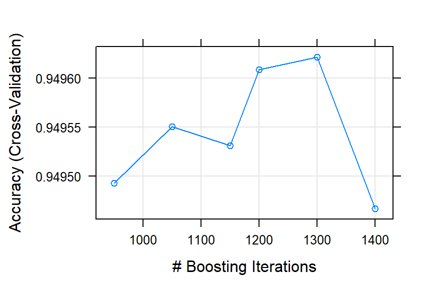

Nous regardons quelle covariable influnce le plus le modèle.

```
gbm variable importance

  only 20 most important variables shown (out of 184)

                                               Overall
extra_outcomepositive                          100.000
weeks_worked_in_year                            74.885
sex Male                                        60.730
educ_levelCollege                               55.259
detailed_occupation_recode2                     42.773
educ_levelgrad-school                           28.249
detailed_occupation_recode7                     28.143
detailed_occupation_recode11                    27.627
groupedeage34 à 62 ans                          27.568
num_persons_worked_for_employer                 22.981
detailed_occupation_recode4                     16.539
detailed_household_and_family_stat Householder  16.065
class_of_worker Self-employed-incorporated      12.648
detailed_occupation_recode5                      6.516
detailed_occupation_recode18                     5.793
detailed_occupation_recode17                     5.585
groupedeage19 à 33 ans                           5.425
detailed_occupation_recode8                      5.155
educ_levelHS-grad                                4.379
detailed_occupation_recode16                     4.272
```

La variable qui influence le plus est **extra_outcome**

#### **Apply model to the test set**

Voici le resultat de la validation :

```
 Accuracy     Kappa
0.9520516 0.4716073
```

```
Confusion Matrix and Statistics

          Reference
Prediction -50000 +50000
    -50000  41212   1678
    +50000    450   1041

               Accuracy : 0.9521
                 95% CI : (0.95, 0.954)
    No Information Rate : 0.9387
    P-Value [Acc > NIR] : < 2.2e-16

                  Kappa : 0.4716

 Mcnemar's Test P-Value : < 2.2e-16

            Sensitivity : 0.9892
            Specificity : 0.3829
         Pos Pred Value : 0.9609
         Neg Pred Value : 0.6982
             Prevalence : 0.9387
         Detection Rate : 0.9286
   Detection Prevalence : 0.9664
      Balanced Accuracy : 0.6860

       'Positive' Class : -50000
```

Nous avons une faible taux d’erreur de validation et elle est équivalant à l’erreur d’apprentissage.

Le kappa est modéré donc accord modéré sur la prédiction par rapport à une prédiction au hasard.

#### **Confusion Table**

Confusion Table Stochastic Gradient Boosting

|  | -50000 | +50000 |
| --- | --- | --- |
| -50000 | 41212 | 1678 |
| +50000 | 450 | 1041 |

Pour cela, on veut savoir :

- combien de outcome avec “- 50 000” seront faussement estimés comme des outcome avec "+50 000 et
- combien de outcome avec “+50 000 ne seront pas estimés comme tels non détectés et classifiés à tort comme outcome avec”- 50 000"

#### **Resultat de la prédiction**

Resultats GBM

|  | Durée | Accuracy | Taux.Erreur | Recall | Precision |
| --- | --- | --- | --- | --- | --- |
| Stochastic Gradient Boosting | 31.22752 mins | 0.9520516 | 0.0479484 | 0.9891988 | 0.9608767 |

Nous avons une bonne performance de prediction pour ce modèle.

### 4.2.2 Classification Tree CART

On va utiliser les fonctions sélectionnées dans le modèle rpart pour l’algorithme CART car il est facile d’utilisation pour un arbre binaire. Et pour la variable outcome la prédiction est binaire.

CART

method = ‘rpart2’

Type: Regression, Classification

Tuning parameters:

- maxdepth (Max Tree Depth)

Required packages: rpart

```
Time difference of 8.034623 mins
```

Voici le resultat de l’apprentissage :

```
CART

155145 samples
    16 predictor
     2 classes: '-50000', '+50000'

No pre-processing
Resampling: Bootstrapped (25 reps)
Summary of sample sizes: 155145, 155145, 155145, 155145, 155145, 155145, ...
Resampling results across tuning parameters:

  maxdepth  Accuracy   Kappa
   1        0.9442048  0.3362598
   2        0.9442048  0.3362598
   3        0.9442048  0.3362598
```

[output cut: 30 more lines]

Nous avons une faible erreur d’apprentissage.

Voici les paramètres choisis :

```
Best parameter pour maxdepth est : 6
```

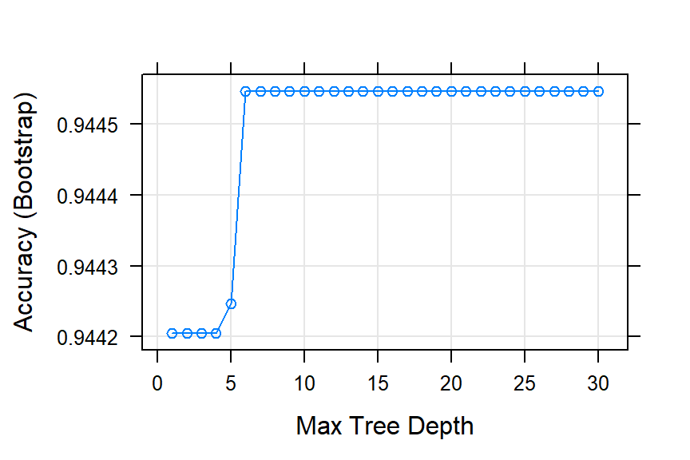

Voici notre arbre. On a utilisé la représentation graphique avec la fonction fancyRpartPlot

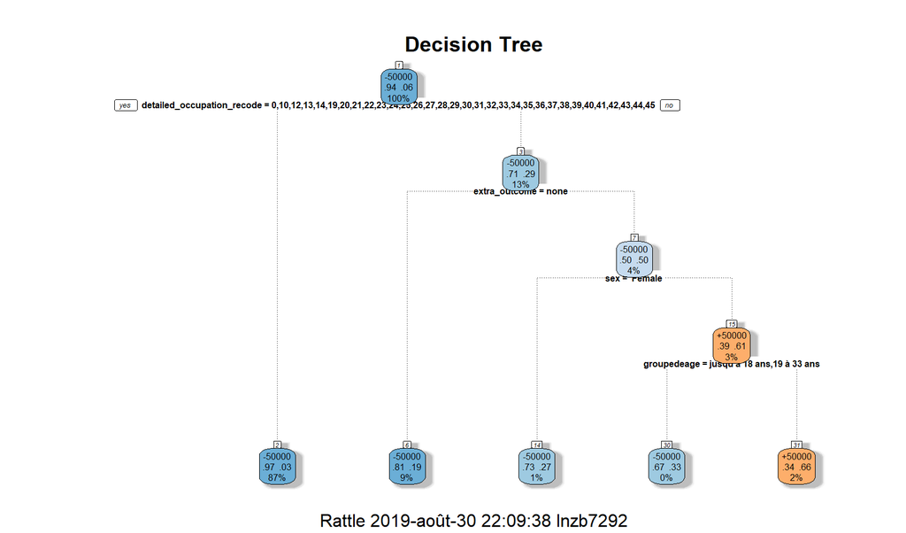

La variable qui influence le plus est **detailed_occupation_recode**

#### **Apply model to the test set**

Voici le resultat de la validation:

```
 Accuracy     Kappa
0.9468692 0.3542823
```

```
Confusion Matrix and Statistics

          Reference
Prediction -50000 +50000
    -50000  41311   2007
    +50000    351    712

               Accuracy : 0.9469
                 95% CI : (0.9447, 0.9489)
    No Information Rate : 0.9387
    P-Value [Acc > NIR] : 1.562e-13

                  Kappa : 0.3543

 Mcnemar's Test P-Value : < 2.2e-16

            Sensitivity : 0.9916
            Specificity : 0.2619
         Pos Pred Value : 0.9537
         Neg Pred Value : 0.6698
             Prevalence : 0.9387
         Detection Rate : 0.9308
   Detection Prevalence : 0.9760
      Balanced Accuracy : 0.6267

       'Positive' Class : -50000
```

Nous avons une faible taux d’erreur de validation et elle est équivalant à l’erreur d’apprentissage.

Le kappa est faible donc accord faible sur la prédiction par rapport à une prédiction au hasard.

#### **Confusion Table**

Confusion Table Classification Tree CART

|  | -50000 | +50000 |
| --- | --- | --- |
| -50000 | 41311 | 2007 |
| +50000 | 351 | 712 |

La matrice de confusion suivante se lit alors comme suit :

#### **Resultat de la prédiction**

Resultats Classification Tree CART

[output not shown]

L’arbre de classification possède un temps d’exécution rapide avec bon taux de précison de la prédiction.

### 4.2.3 Random Forest

Nous allons utiliser random Forest qui utilise le bagging et donc prend en compte la majorité des variables.

Random Forest

method = ‘rf’

Type: Classification, Regression

Tuning parameters:

- mtry (#Randomly Selected Predictors)

Required packages: randomForest

A model-specific variable importance metric is available

#### **Fine-Tuning Hyperparameters avec Cross Validation et Grid Search**

Nous utilisons le paramètre number=2.

```
Time difference of 14.98683 mins
```

Voici le resultat de l’apprentissage :

```
Random Forest

19322 samples
   16 predictor
    2 classes: '-50000', '+50000'

No pre-processing
Resampling: Cross-Validated (2 fold)
Summary of sample sizes: 9661, 9661
Resampling results across tuning parameters:

  mtry  Accuracy   Kappa
   8    0.8564848  0.7129695
  12    0.8566919  0.7133834
  16    0.8559155  0.7118308
  20    0.8549840  0.7099677

Accuracy was used to select the optimal model using the largest value.
The final value used for the model was mtry = 12.
```

Nous avons une plus grande erreur d’apprentissage sur ce modèle par rapport aux premiers.

Voici les paramètres choisis :

```
Best parameter pour mtry est : 12
```

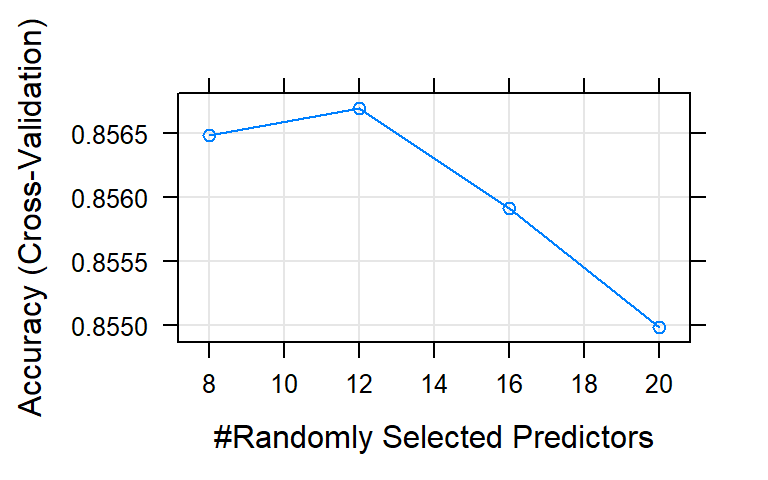

#### **Apply model to the test set**

```
 Accuracy     Kappa
0.8341407 0.3370920
```

```
Confusion Matrix and Statistics

          Reference
Prediction -50000 +50000
    -50000  34563    262
    +50000   7099   2457

               Accuracy : 0.8341
                 95% CI : (0.8306, 0.8376)
    No Information Rate : 0.9387
    P-Value [Acc > NIR] : 1

                  Kappa : 0.3371

 Mcnemar's Test P-Value : <2e-16

            Sensitivity : 0.8296
            Specificity : 0.9036
         Pos Pred Value : 0.9925
         Neg Pred Value : 0.2571
             Prevalence : 0.9387
         Detection Rate : 0.7788
   Detection Prevalence : 0.7847
      Balanced Accuracy : 0.8666

       'Positive' Class : -50000
```

Nous avons une faible taux d’erreur de validation et elle est équivalant à l’erreur d’apprentissage.

Le kappa est faible donc accord faible sur la prédiction par rapport à une prédiction au hasard.

#### **Confusion Table**

Confusion Table Random Forest

|  | -50000 | +50000 |
| --- | --- | --- |
| -50000 | 34563 | 262 |
| +50000 | 7099 | 2457 |

La matrice de confusion suivante se lit alors comme suit :

#### **Resultat de la prédiction**

Resultats Random Forest

[output not shown]

Nous avons une bonne accuracy pour la prédiction mais le temps d’excution est long.

### 4.2.4 Naive Bayes

On va utiliser l’algorithme naïf bayésien qui est l’une des méthodes les plus simples en apprentissage supervisé basée sur le théorème de Bayes. Il est peu utilisé par rapport aux arbres de décision ou les régressions logistiques mais il est facile d’estimer des paramètres et il est rapide.

Naive Bayes

method = ‘nb’

Type: Classification

Tuning parameters:

- fL (Laplace Correction)
  - usekernel (Distribution Type) = TRUE, FALSE
  - adjust (Bandwidth Adjustment)

Required packages: klaR

#### **Fine-Tuning Hyperparameters avec Cross Validation et Grid Search**

Nous utilisons le paramètre number=10.

```
Time difference of 5.327326 mins
```

Voici le resultat de l’apprentissage :

```
Naive Bayes

19322 samples
   16 predictor
    2 classes: '-50000', '+50000'

No pre-processing
Resampling: Cross-Validated (10 fold)
Summary of sample sizes: 17389, 17390, 17390, 17390, 17390, 17390, ...
Resampling results across tuning parameters:

  usekernel  Accuracy  Kappa
  FALSE      NaN       NaN
   TRUE      0.5         0

Tuning parameter 'fL' was held constant at a value of 0
Tuning
 parameter 'adjust' was held constant at a value of 1
Accuracy was used to select the optimal model using the largest value.
The final values used for the model were fL = 0, usekernel = TRUE
 and adjust = 1.
```

Nous avons un faible résultat d’apprentissage.

Voici les paramètres choisis :

```
Best parameter pour fL est : 0
```

```
Best parameter pour usekernel est : TRUE
```

```
Best parameter pour adjust est : 1
```

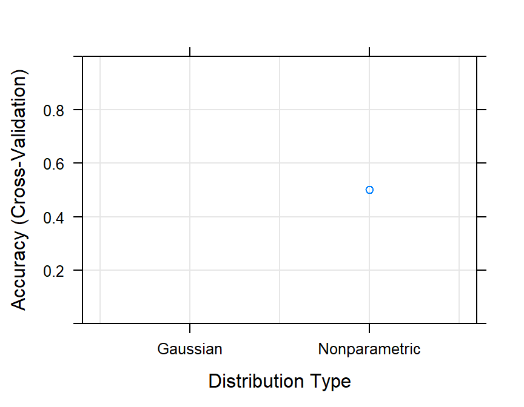

#### **Apply model to the test set**

```
Accuracy    Kappa
0.938735 0.000000
```

```
Confusion Matrix and Statistics

          Reference
Prediction -50000 +50000
    -50000  41662   2719
    +50000      0      0

               Accuracy : 0.9387
                 95% CI : (0.9365, 0.9409)
    No Information Rate : 0.9387
    P-Value [Acc > NIR] : 0.5051

                  Kappa : 0

 Mcnemar's Test P-Value : <2e-16

            Sensitivity : 1.0000
            Specificity : 0.0000
         Pos Pred Value : 0.9387
         Neg Pred Value :    NaN
             Prevalence : 0.9387
         Detection Rate : 0.9387
   Detection Prevalence : 1.0000
      Balanced Accuracy : 0.5000

       'Positive' Class : -50000
```

Le kappa est null donc désaccord sur la prédiction par rapport à une prédiction au hasard.

La spécificité (la capacité du test à prédire une admission quand celle-ci a réellement eu lieu) est à 0. Le modèle a prédit 0 valeurs outcome +50000.

#### **Confusion Table**

Confusion Table Naives bayes

|  | -50000 | +50000 |
| --- | --- | --- |
| -50000 | 41662 | 2719 |
| +50000 | 0 | 0 |

Il n’y a aucune prédiction correcte pour le outcome +50000.

La matrice de confusion suivante se lit alors comme suit :

#### Resultat de la prédiction

Resultats Naives bayes

|  | Durée | Accuracy | Taux.Erreur | Recall | Precision |
| --- | --- | --- | --- | --- | --- |
| Naives bayes | 5.327326 mins | 0.938735 | 0.061265 | 1 | 0.938735 |

### 4.2.5 Support vector machine linéaire

Nous allons utiliser un modèle SVM de type linéaire.

Support Vector Machines with Linear Kernel

method = ‘svmLinear’

Type: Regression, Classification

Tuning parameters:

- C (Cost)

Required packages: kernlab

#### **Fine-Tuning Hyperparameters avec repeated Cros Validation et Grid Search**

Nous utilisons le paramètre number=2.

```
Time difference of 20.34367 mins
```

```
Support Vector Machines with Linear Kernel

19322 samples
   16 predictor
    2 classes: '-50000', '+50000'

Pre-processing: centered (184), scaled (184)
Resampling: Cross-Validated (2 fold)
Summary of sample sizes: 9661, 9661
Resampling results across tuning parameters:

  cost  Accuracy   Kappa
  0.2   0.8581410  0.7162822
  0.4   0.8581927  0.7163857
  0.6   0.8581927  0.7163857
  0.8   0.8582962  0.7165927
  1.0   0.8581927  0.7163857
  1.2   0.8582445  0.7164892
  1.4   0.8582445  0.7164892

Accuracy was used to select the optimal model using the smallest value.
The final value used for the model was cost = 0.2.
```

L’erreur est faible et le kappa est élevé avec un accord fort

Voici les paramètres choisis :

```
Best parameter pour cost est : 0.2
```

#### **Apply the tree to test set**

Voici le resultat de la validation :

```
 Accuracy     Kappa
0.8370474 0.3424217
```

```
Confusion Matrix and Statistics

          Reference
Prediction -50000 +50000
    -50000  34688    258
    +50000   6974   2461

               Accuracy : 0.837
                 95% CI : (0.8336, 0.8405)
    No Information Rate : 0.9387
    P-Value [Acc > NIR] : 1

                  Kappa : 0.3424

 Mcnemar's Test P-Value : <2e-16

            Sensitivity : 0.8326
            Specificity : 0.9051
         Pos Pred Value : 0.9926
         Neg Pred Value : 0.2608
             Prevalence : 0.9387
         Detection Rate : 0.7816
   Detection Prevalence : 0.7874
      Balanced Accuracy : 0.8689

       'Positive' Class : -50000
```

L’erreur est faible et le kappa est faible avec un accord faible sur la prédiction

#### **Confusion Table**

Confusion Table SVM

|  | -50000 | +50000 |
| --- | --- | --- |
| -50000 | 34688 | 258 |
| +50000 | 6974 | 2461 |

La matrice de confusion suivante se lit alors comme suit :

#### **Resultat de la prédiction**

Resultats SVM Linear

|  | Durée | Accuracy | Taux.Erreur | Recall | Precision |
| --- | --- | --- | --- | --- | --- |
| Support vector machine linéaire | 20.34367 mins | 0.8370474 | 0.1629526 | 0.8326053 | 0.9926172 |

Le temps d’execution est long et la prédiction est bonne

### 4.2.6 Support vector machine à noyau

Nous allons utilisé SVM de type Radial Basis Function Kernel

method = ‘svmRadialSigma’

Type: Regression, Classification

Tuning parameters:

- sigma (Sigma)
  - C (Cost)

Required packages: kernlab

Nous utilisons le paramètre number=2.

#### **Fine-Tuning avec recherche des Hyperparameters avec Cross Validation et Grid Search**

Nous utilisons number = 2 car le temps d’execution est trop long.

```
Time difference of 27.54678 mins
```

Voici le resultat de l’apprentissage :

```
Support Vector Machines with Radial Basis Function Kernel

19322 samples
   16 predictor
    2 classes: '-50000', '+50000'

Pre-processing: centered (184), scaled (184)
Resampling: Cross-Validated (2 fold)
Summary of sample sizes: 9661, 9661
Resampling results across tuning parameters:

  sigma  C     Accuracy   Kappa
  0.010  0.75  0.8440120  0.6880241
  0.010  1.00  0.8440120  0.6880241
  0.010  1.25  0.8431839  0.6863679
  0.015  0.75  0.8399752  0.6799503
  0.015  1.00  0.8394059  0.6788118
  0.015  1.25  0.8382673  0.6765346
  0.200  0.75  0.7349653  0.4699308
  0.200  1.00  0.7447987  0.4895976
  0.200  1.25  0.7493013  0.4986027

Accuracy was used to select the optimal model using the smallest value.
The final values used for the model were sigma = 0.2 and C = 0.75.
```

Voici les paramètres choisis :

```
Best parameter pour sigma  est : 0.2
```

```
Best parameter pour C est : 0.75
```

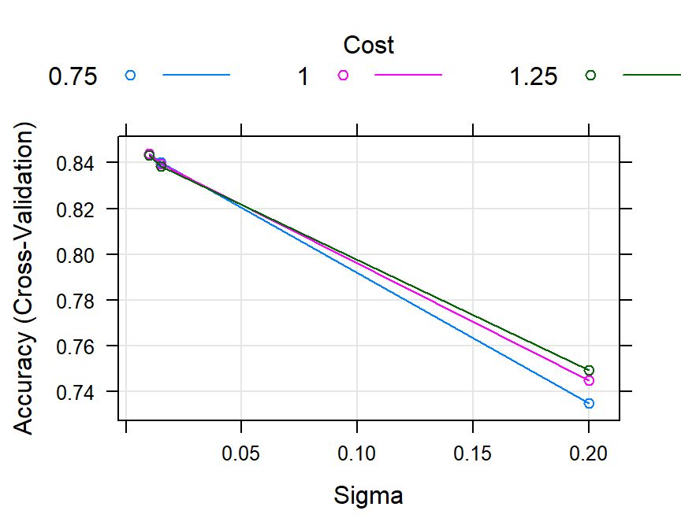

#### **Apply model to the test set**

```
 Accuracy     Kappa
0.5627633 0.1155063
```

```
Confusion Matrix and Statistics

          Reference
Prediction -50000 +50000
    -50000  22367    110
    +50000  19295   2609

               Accuracy : 0.5628
                 95% CI : (0.5581, 0.5674)
    No Information Rate : 0.9387
    P-Value [Acc > NIR] : 1

                  Kappa : 0.1155

 Mcnemar's Test P-Value : <2e-16

            Sensitivity : 0.5369
            Specificity : 0.9595
         Pos Pred Value : 0.9951
         Neg Pred Value : 0.1191
             Prevalence : 0.9387
         Detection Rate : 0.5040
   Detection Prevalence : 0.5065
      Balanced Accuracy : 0.7482

       'Positive' Class : -50000
```

Nous avons une grande erreur de validation et il est pls grand que l’ erreur d’apprentissage. Nous avons un problème de sur apprentissage. Le kappa est faible avec un accord faible de prédiction

#### **Confusion Table**

Confusion Table SVM radial

|  | -50000 | +50000 |
| --- | --- | --- |
| -50000 | 22367 | 110 |
| +50000 | 19295 | 2609 |

La matrice de confusion suivante se lit alors comme suit :

#### Resultat de la prédiction

Resultats SVM Radial

|  | Durée | Accuracy | Taux.Erreur | Recall | Precision |
| --- | --- | --- | --- | --- | --- |
| Support vector machine Radial | 27.54678 mins | 0.5627633 | 0.4372367 | 0.5368681 | 0.9951061 |

### 4.2.7 K Plus proche voisins KNN

Le k Nearest Neighbors (KNN) est un algorithme qui peut servir autant pour la classification que la régression. L’algorithme Le plus proches voisins consiste à choisir les k données les plus proches du point étudié afin d’en prédire sa valeur.

k-Nearest Neighbors

method = ‘knn’

Type: Classification, Regression

Tuning parameters:

- k (#Neighbors)

Nous utilisons le paramètre number=10 et pas de répétitions car le temps d’execution est trop long.

#### **Fine-Tuning recherche des Hyperparameters avec Cross-Validation et Grid search**

```
Time difference of 13.29267 mins
```

Voici le resultat de l’apprentissage :

```
k-Nearest Neighbors

19322 samples
   16 predictor
    2 classes: '-50000', '+50000'

No pre-processing
Resampling: Cross-Validated (10 fold)
Summary of sample sizes: 17390, 17390, 17390, 17390, 17390, 17390, ...
Resampling results across tuning parameters:

  k   Accuracy   Kappa
   1  0.8307107  0.6614214
   4  0.8442706  0.6885411
   7  0.8463929  0.6927856
  10  0.8486181  0.6972361
  13  0.8471171  0.6942338

Accuracy was used to select the optimal model using the largest value.
The final value used for the model was k = 10.
```

Nous avons une faible erreur d’apprentissage. Le kappa est élevé avec un accord élevé de prédiction

Voici les paramètres choisis :

```
Best parameter pour k est : 10
```

Nous regardons quelle covariable influnce le plus le modèle.

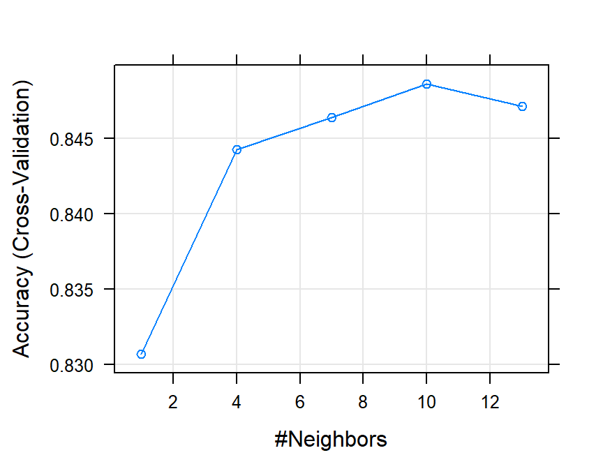

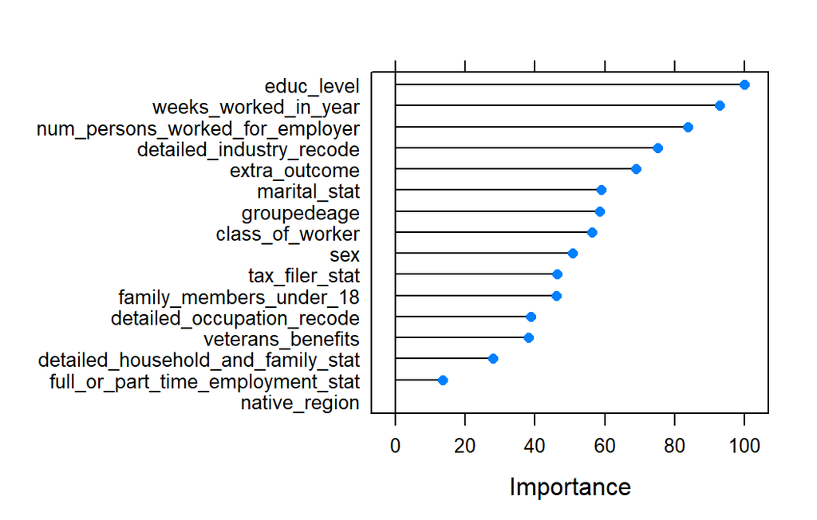

Nous avons **educ_level, num_persons_worked_for_employer**, **detailed_industry_recode,weeks_worked_in_year** qui influencent beaucoup le modèle.

#### **Apply the tree to test set**

Voici le resultat de la validation:

```
 Accuracy     Kappa
0.8125099 0.3027596
```

```
Confusion Matrix and Statistics

          Reference
Prediction -50000 +50000
    -50000  33610    269
    +50000   8052   2450

               Accuracy : 0.8125
                 95% CI : (0.8088, 0.8161)
    No Information Rate : 0.9387
    P-Value [Acc > NIR] : 1

                  Kappa : 0.3028

 Mcnemar's Test P-Value : <2e-16

            Sensitivity : 0.8067
            Specificity : 0.9011
         Pos Pred Value : 0.9921
         Neg Pred Value : 0.2333
             Prevalence : 0.9387
         Detection Rate : 0.7573
   Detection Prevalence : 0.7634
      Balanced Accuracy : 0.8539

       'Positive' Class : -50000
```

Nous avons une erreur de validation plus élevé que l’erreur d’apprentissage. Le kappa est faible avec un accord faible de prédiction.

#### **Confusion Table**

Confusion Table KNN

|  | -50000 | +50000 |
| --- | --- | --- |
| -50000 | 33610 | 269 |
| +50000 | 8052 | 2450 |

La matrice de confusion suivante se lit alors comme suit :

#### **Resultat de la prédiction**

Resultats KNN

|  | Durée | Accuracy | Taux.Erreur | Recall | Precision |
| --- | --- | --- | --- | --- | --- |
| K nearest neighbors KNN | 13.29267 mins | 0.8125099 | 0.1874901 | 0.8067304 | 0.99206 |

Nous avons trouver une stratégie pour avoir une valeur optimale pour le paramètre k. Le niveau de prediction est bon avec un temps d’exécution correcte.

### 4.2.8 Neural Networks

Les réseaux neuronaux sont l’un des modèles d’apprentissage machine les plus fascinants car leur structure est inspirée par le cerveau.

Neural Network

method = ‘nnet’

Type: Classification, Regression

Tuning parameters:

- size (#Hidden Units)
  - decay (Weight Decay)

Required packages: nnet

A model-specific variable importance metric is available.

#### **Fine-Tuning recherche des Hyperparameters avec Cross validation et grid search**

Voici le resultat de l’apprentissage :

```
Neural Network

155145 samples
    16 predictor
     2 classes: '-50000', '+50000'

No pre-processing
Resampling: Cross-Validated (2 fold)
Summary of sample sizes: 77572, 77573
Resampling results across tuning parameters:

  size  decay  Accuracy   Kappa
  2     0.2    0.9489832  0.4507088
  2     0.5    0.9490154  0.4468607
  2     0.8    0.9489961  0.4404776
  2     1.0    0.9433111  0.2273694
  3     0.2    0.9484676  0.4380545
  3     0.5    0.9494408  0.4358074
  3     0.8    0.9491508  0.4469613
  3     1.0    0.9490090  0.4366423
  4     0.2    0.9487769  0.4399896
  4     0.5    0.9480937  0.4046013
  4     0.8    0.9492604  0.4475999
  4     1.0    0.9494151  0.4476317

Accuracy was used to select the optimal model using the largest value.
The final values used for the model were size = 3 and decay = 0.5.
```

Nous avons une faible erreur d’apprentissage. Le kappa est modéré avec un accord modéré de prédiction

Voici les paramètres choisis :

```
Best parameter pour size est : 3
```

```
Best parameter pour decay  est : 0.5
```

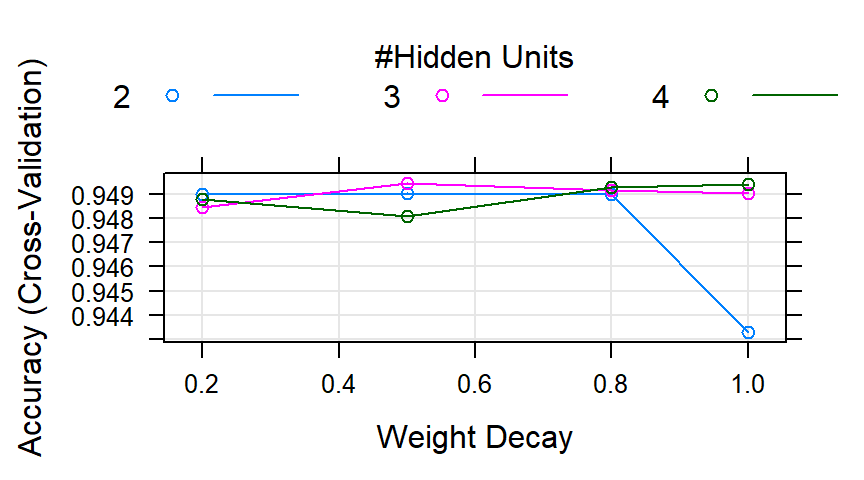

Nous regardons quelle covariable influnce le plus le modèle.

```
nnet variable importance

  only 20 most important variables shown (out of 184)

                                                                         Overall
detailed_occupation_recode7                                               100.00
sex Male                                                                   92.78
tax_filer_stat Nonfiler                                                    78.33
family_members_under_18 Not in universe                                    71.20
extra_outcomepositive                                                      68.42
tax_filer_stat Joint both under 65                                         62.35
detailed_household_and_family_stat Child <18 never marr not in subfamily   57.73
detailed_occupation_recode39                                               53.07
detailed_occupation_recode2                                                51.62
educ_levelno-HS                                                            50.62
detailed_occupation_recode11                                               50.10
detailed_industry_recode20                                                 46.54
detailed_household_and_family_stat Secondary individual                    45.48
detailed_occupation_recode26                                               41.78
marital_stat Married-civilian spouse present                               40.73
detailed_industry_recode33                                                 40.26
detailed_occupation_recode5                                                40.25
detailed_industry_recode44                                                 40.06
detailed_occupation_recode27                                               38.71
detailed_occupation_recode25                                               38.58
```

Le graphe **plotnet** du réseau de neurones:

[figure not shown]